# Exploratory Analysis of U.S. NOAA Storm Events, 2024

Nuzaif Naveed

2025-05-02

## Synopsis

This analysis explores the 2024 NOAA Storm Events database to identify patterns in storm-related fatalities, injuries, event frequencies, seasonal behaviors, and economic damages across the United States. The dataset, obtained from three interlinked files (event details, locations, and fatalities), was merged and cleaned for analysis.

Key findings include: - The most harmful event types to population health - The most common weather event types in each state - Seasonal patterns of storm event occurrences - The types of events with the greatest economic impact

This report is intended for emergency management professionals and analysts who may need to prioritize resources based on the type, location, and impact of severe weather events.

## Data Processing

The raw data files were read from NOAA’s Storm Events archive, joined by `EVENT_ID`, and cleaned to address missing values and standardize variables. Below is the code for data loading, merging, missingness visualization, and preprocessing.

```r
# Clear the workspace — removes all existing variables to prevent conflicts
rm(list = ls())

# Load required packages
# dplyr: data manipulation
# readr: efficient CSV reading
# naniar: missing data visualization
# ggplot2: plotting
# scales: formatting numeric outputs (e.g., currency)
library(dplyr)
library(readr)
library(naniar)
library(ggplot2)
library(scales)

# Set the folder path where your unzipped data files are stored
# Update this path if your files are saved in a different location
folder_path <- "D:/MS Data Analytics/Fall 2024/DAT 511/Final Project/Data_Stewardship_Storm_Events_Project"

# Define file paths for the three NOAA data files: details, fatalities, locations
details_file <- file.path(folder_path, "data", "StormEvents_details-ftp_v1.0_d2024_c20250401.csv.gz")
fatalities_file <- file.path(folder_path, "data", "StormEvents_fatalities-ftp_v1.0_d2024_c20250401.csv.gz")
locations_file <- file.path(folder_path, "data", "StormEvents_locations-ftp_v1.0_d2024_c20250401.csv.gz")

# Read the CSV files directly from compressed .gz format
details <- read_csv(details_file)
fatalities <- read_csv(fatalities_file)
locations <- read_csv(locations_file)

# Merge the three datasets using the common key: EVENT_ID
# - Each EVENT_ID represents one storm event
# - 'details' is the base file; we enrich it by joining with 'locations' and then 'fatalities'
joined_data <- details %>%
  left_join(locations, by = "EVENT_ID") %>%
  left_join(fatalities, by = "EVENT_ID")

# Save the joined dataset to a local CSV file (optional, for inspection outside R)
output_file <- file.path(folder_path, "StormEvents_joined_data.csv")
write_csv(joined_data, output_file)

# View the first few rows to confirm successful loading and joining
print(head(joined_data))
```

```
## # A tibble: 6 × 71
##   BEGIN_YEARMONTH BEGIN_DAY BEGIN_TIME END_YEARMONTH END_DAY END_TIME
##             <dbl>     <dbl>      <dbl>         <dbl>   <dbl>    <dbl>
## 1          202405        23       1947        202405      23     1947
## 2          202411        16        230        202411      18     1421
## 3          202405        19       1839        202405      19     1902
## 4          202405        23       2155        202405      23     2155
## 5          202405        24       1405        202405      24     1410
## 6          202411         1          0        202411       1     1600
## # ℹ 65 more variables: EPISODE_ID.x <dbl>, EVENT_ID <dbl>, STATE <chr>,
## #   STATE_FIPS <dbl>, YEAR <dbl>, MONTH_NAME <chr>, EVENT_TYPE <chr>,
## #   CZ_TYPE <chr>, CZ_FIPS <dbl>, CZ_NAME <chr>, WFO <chr>,
## #   BEGIN_DATE_TIME <chr>, CZ_TIMEZONE <chr>, END_DATE_TIME <chr>,
## #   INJURIES_DIRECT <dbl>, INJURIES_INDIRECT <dbl>, DEATHS_DIRECT <dbl>,
## #   DEATHS_INDIRECT <dbl>, DAMAGE_PROPERTY <chr>, DAMAGE_CROPS <chr>,
## #   SOURCE <chr>, MAGNITUDE <dbl>, MAGNITUDE_TYPE <chr>, FLOOD_CAUSE <chr>, …
```

```r
# View a summary of column names, data types, and sample values
glimpse(joined_data)
```

```
## Rows: 89,860
## Columns: 71
## $ BEGIN_YEARMONTH    <dbl> 202405, 202411, 202405, 202405, 202405, 202411, 202…
## $ BEGIN_DAY          <dbl> 23, 16, 19, 23, 24, 1, 1, 14, 14, 17, 13, 17, 17, 1…
## $ BEGIN_TIME         <dbl> 1947, 230, 1839, 2155, 1405, 0, 0, 1510, 1352, 1100…
## $ END_YEARMONTH      <dbl> 202405, 202411, 202405, 202405, 202405, 202411, 202…
## $ END_DAY            <dbl> 23, 18, 19, 23, 24, 1, 1, 14, 14, 18, 13, 18, 18, 1…
## $ END_TIME           <dbl> 1947, 1421, 1902, 2155, 1410, 1600, 1600, 1515, 135…
## $ EPISODE_ID.x       <dbl> 190907, 197838, 190905, 190907, 191916, 197531, 197…
## $ EVENT_ID           <dbl> 1180619, 1223377, 1184919, 1180805, 1182348, 122190…
## $ STATE              <chr> "OKLAHOMA", "OREGON", "OKLAHOMA", "OKLAHOMA", "MISS…
## $ STATE_FIPS         <dbl> 40, 41, 40, 40, 28, 53, 41, 28, 47, 41, 53, 41, 41,…
## $ YEAR               <dbl> 2024, 2024, 2024, 2024, 2024, 2024, 2024, 2024, 202…
## $ MONTH_NAME         <chr> "May", "November", "May", "May", "May", "November",…
## $ EVENT_TYPE         <chr> "Hail", "Heavy Snow", "Tornado", "Thunderstorm Wind…
```

[output cut: 58 more lines]

```r
# Sample 5,000 rows for plotting
set.seed(786)
sample_data <- joined_data %>% sample_n(5000)

# Calculate % missing values in each column
missing_prop <- colMeans(is.na(sample_data))

# Highlight variables with >80% missing
missing_prop <- colMeans(is.na(sample_data))
highlight_vars <- names(missing_prop[missing_prop > 0.8])
```

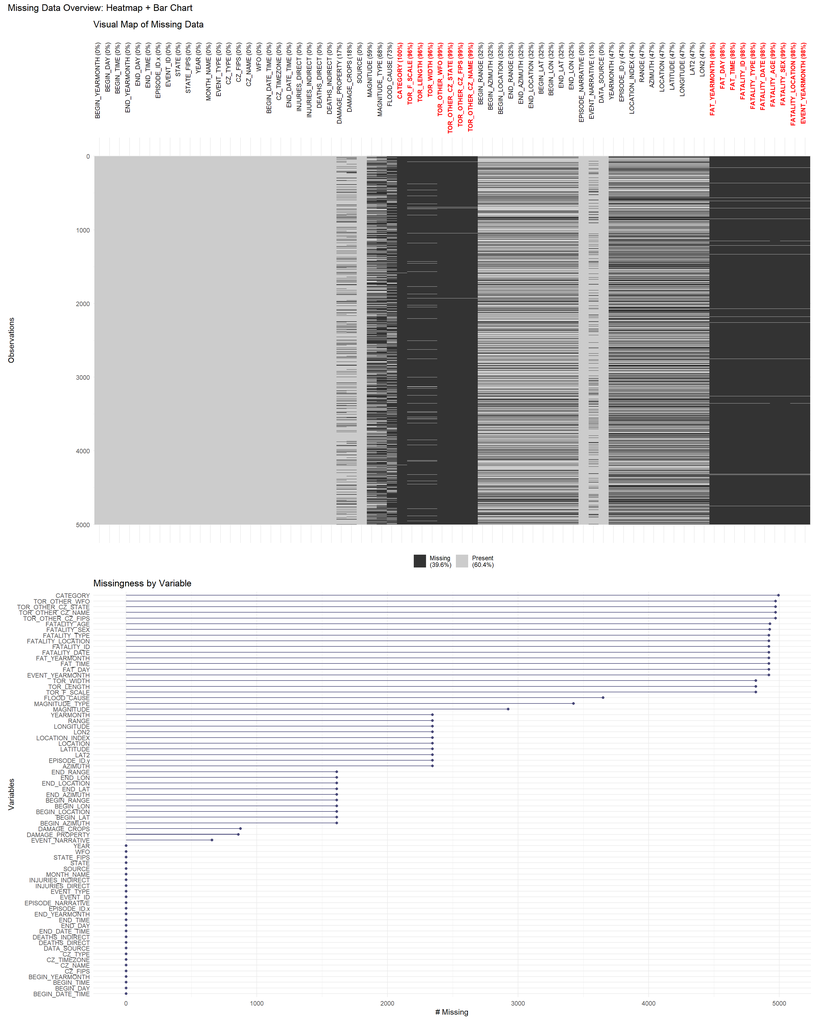

```r
library(patchwork)

# Plot 1: Visual missingness heatmap
plot1 <- vis_miss(sample_data) +
  theme(axis.text.x = element_text(
    angle = 90,
    vjust = 0.5,
    hjust = 1,
    color = ifelse(names(sample_data) %in% highlight_vars, "red", "black"),
    face = ifelse(names(sample_data) %in% highlight_vars, "bold", "plain")
  )) +
  labs(title = "Visual Map of Missing Data")

# Plot 2: Bar chart of missing values
plot2 <- gg_miss_var(sample_data) +
  labs(title = "Missingness by Variable")

# Combine the two vertically
plot1 / plot2 +
  plot_annotation(title = "Missing Data Overview: Heatmap + Bar Chart")
```

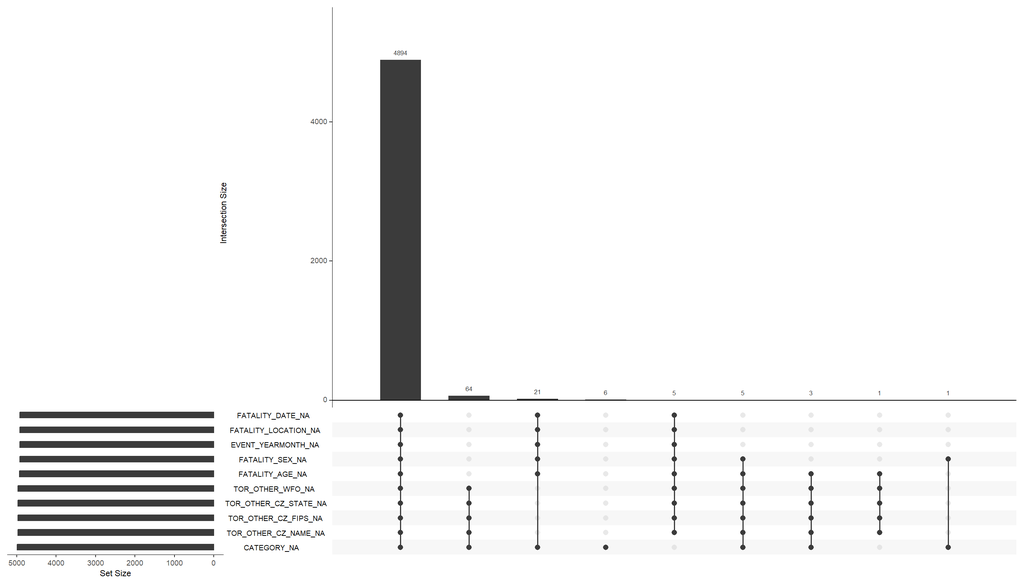

```r
gg_miss_upset(sample_data, nsets = 10)
```

```r
# Compute missingness percentage across the full dataset
missing_summary <- colSums(is.na(joined_data)) / nrow(joined_data) * 100

# Sort to view highest missingness first
missing_summary <- sort(missing_summary, decreasing = TRUE)
print(missing_summary)
```

```
##           CATEGORY      TOR_OTHER_WFO TOR_OTHER_CZ_STATE  TOR_OTHER_CZ_FIPS
##           99.93657           99.41353           99.41353           99.41353
##  TOR_OTHER_CZ_NAME       FATALITY_AGE       FATALITY_SEX      FAT_YEARMONTH
##           99.41353           98.72023           98.63009           98.51547
##            FAT_DAY           FAT_TIME        FATALITY_ID      FATALITY_TYPE
##           98.51547           98.51547           98.51547           98.51547
##      FATALITY_DATE  FATALITY_LOCATION    EVENT_YEARMONTH        TOR_F_SCALE
##           98.51547           98.51547           98.51547           96.38549
##         TOR_LENGTH          TOR_WIDTH        FLOOD_CAUSE     MAGNITUDE_TYPE
##           96.38549           96.38549           72.40485           68.59448
##          MAGNITUDE          YEARMONTH       EPISODE_ID.y     LOCATION_INDEX
##           58.44425           46.27309           46.27309           46.27309
##              RANGE            AZIMUTH           LOCATION           LATITUDE
##           46.27309           46.27309           46.27309           46.27309
##          LONGITUDE               LAT2               LON2        BEGIN_RANGE
##           46.27309           46.27309           46.27309           31.23748
##      BEGIN_AZIMUTH     BEGIN_LOCATION          END_RANGE        END_AZIMUTH
##           31.23748           31.23748           31.23748           31.23748
##       END_LOCATION          BEGIN_LAT          BEGIN_LON            END_LAT
##           31.23748           31.23748           31.23748           31.23748
##            END_LON       DAMAGE_CROPS    DAMAGE_PROPERTY    EVENT_NARRATIVE
##           31.23748           17.84554           17.38037           13.45538
##    BEGIN_YEARMONTH          BEGIN_DAY         BEGIN_TIME      END_YEARMONTH
##            0.00000            0.00000            0.00000            0.00000
##            END_DAY           END_TIME       EPISODE_ID.x           EVENT_ID
##            0.00000            0.00000            0.00000            0.00000
##              STATE         STATE_FIPS               YEAR         MONTH_NAME
##            0.00000            0.00000            0.00000            0.00000
##         EVENT_TYPE            CZ_TYPE            CZ_FIPS            CZ_NAME
##            0.00000            0.00000            0.00000            0.00000
##                WFO    BEGIN_DATE_TIME        CZ_TIMEZONE      END_DATE_TIME
##            0.00000            0.00000            0.00000            0.00000
##    INJURIES_DIRECT  INJURIES_INDIRECT      DEATHS_DIRECT    DEATHS_INDIRECT
##            0.00000            0.00000            0.00000            0.00000
##             SOURCE  EPISODE_NARRATIVE        DATA_SOURCE
##            0.00000            0.00000            0.00000
```

```r
# Identify columns with more than 90% missing data
# These columns are typically not useful for analysis and clutter the dataset
cols_to_drop <- names(missing_summary[missing_summary > 90])

# Drop high-missingness columns from dataset
joined_data_cleaned <- joined_data %>%
  select(-all_of(cols_to_drop))

# Display which columns were dropped for transparency
cat("Dropped columns with >90% missingness:\n")
```

```
## Dropped columns with >90% missingness:
```

```r
print(cols_to_drop)
```

```
##  [1] "CATEGORY"           "TOR_OTHER_WFO"      "TOR_OTHER_CZ_STATE"
##  [4] "TOR_OTHER_CZ_FIPS"  "TOR_OTHER_CZ_NAME"  "FATALITY_AGE"
##  [7] "FATALITY_SEX"       "FAT_YEARMONTH"      "FAT_DAY"
## [10] "FAT_TIME"           "FATALITY_ID"        "FATALITY_TYPE"
## [13] "FATALITY_DATE"      "FATALITY_LOCATION"  "EVENT_YEARMONTH"
## [16] "TOR_F_SCALE"        "TOR_LENGTH"         "TOR_WIDTH"
```

## Results

Below are the analyses to address the key research questions.

### Question 1: Across the United States, which types of events (as indicated in the EVENT_TYPE variable) are most harmful with respect to population health?

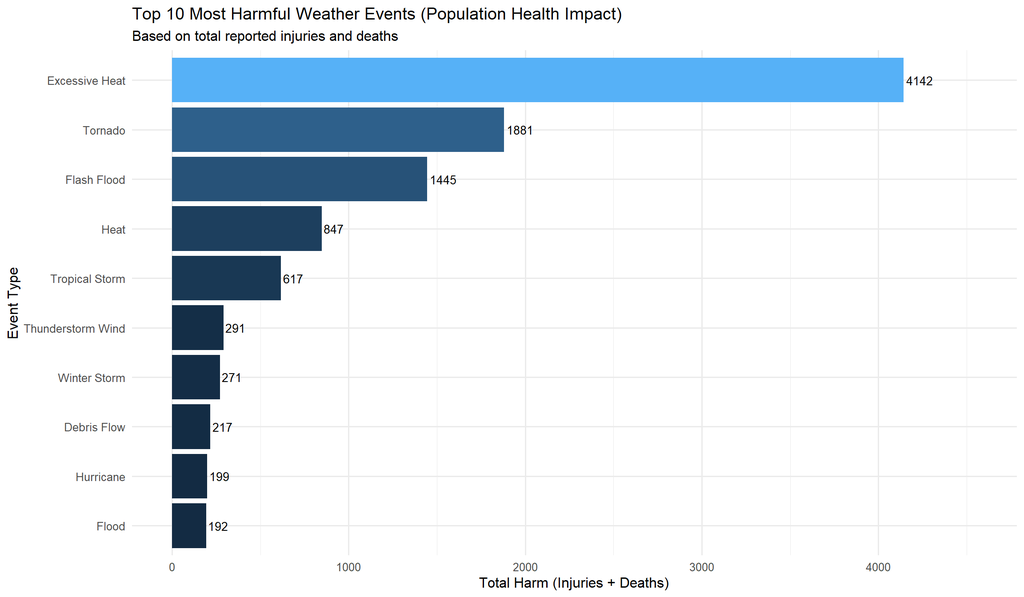

```r
# Select key columns related to fatalities and injuries.
health_data <- joined_data_cleaned %>%
  select(EVENT_ID, EVENT_TYPE, STATE, DEATHS_DIRECT, DEATHS_INDIRECT, INJURIES_DIRECT, INJURIES_INDIRECT)

# Convert state names to uppercase (for standardization) and filter for US states.
us_states <- c(state.name, "District of Columbia") %>% toupper()
health_data <- health_data %>%
  filter(STATE %in% us_states)

# Calculate total harm by summing deaths and injuries.
health_data <- health_data %>%
  mutate(TOTAL_HARM = DEATHS_DIRECT + DEATHS_INDIRECT + INJURIES_DIRECT + INJURIES_INDIRECT)

# Group data by event type and compute total fatalities, injuries, and overall harm.
event_harm_summary <- health_data %>%
  group_by(EVENT_TYPE) %>%
  summarise(
    TOTAL_DEATHS = sum(DEATHS_DIRECT + DEATHS_INDIRECT, na.rm = TRUE),
    TOTAL_INJURIES = sum(INJURIES_DIRECT + INJURIES_INDIRECT, na.rm = TRUE),
    TOTAL_HARM = sum(TOTAL_HARM, na.rm = TRUE)
  ) %>%
  arrange(desc(TOTAL_HARM))

# Plot the top 10 most harmful weather events.
event_harm_summary %>%
  slice_max(TOTAL_HARM, n = 10) %>%
  ggplot(aes(x = reorder(EVENT_TYPE, TOTAL_HARM), y = TOTAL_HARM, fill = TOTAL_HARM)) +
  geom_col(show.legend = FALSE) +
  geom_text(aes(label = TOTAL_HARM), hjust = -0.1, size = 3.5, color = "black") +
  coord_flip() +
  labs(
    title = "Top 10 Most Harmful Weather Events (Population Health Impact)",
    subtitle = "Based on total reported injuries and deaths",
    x = "Event Type",
    y = "Total Harm (Injuries + Deaths)"
  ) +
  theme_minimal(base_size = 12) +
  expand_limits(y = max(event_harm_summary$TOTAL_HARM) * 1.1)
```

### Question 2: Across the United States, which types of events most happening in which States?

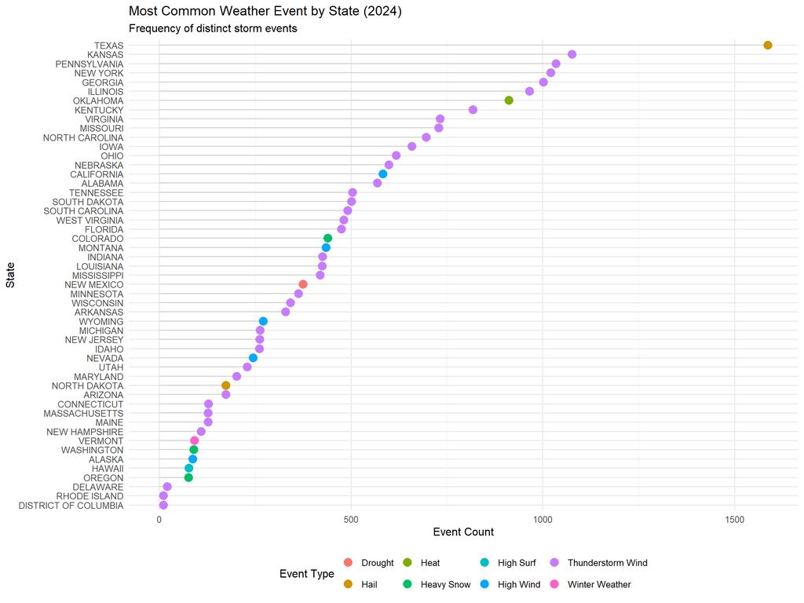

```r
# Deduplicate to the event level to avoid counting duplicates.
event_level_data <- health_data %>%
  distinct(EVENT_ID, STATE, EVENT_TYPE, .keep_all = TRUE)

# Count unique events per state and event type.
event_counts_by_state <- event_level_data %>%
  group_by(STATE, EVENT_TYPE) %>%
  summarise(EVENT_COUNT = n(), .groups = "drop")

# For each state, identify the most common event type.
most_common_event_by_state <- event_counts_by_state %>%
  group_by(STATE) %>%
  slice_max(EVENT_COUNT, n = 1, with_ties = FALSE) %>%
  arrange(STATE)

# Plot the most frequent event per state.
ggplot(most_common_event_by_state, aes(x = reorder(STATE, EVENT_COUNT), y = EVENT_COUNT)) +
  geom_segment(aes(xend = STATE, y = 0, yend = EVENT_COUNT), color = "gray80") +
  geom_point(aes(color = EVENT_TYPE), size = 4) +
  coord_flip() +
  labs(
    title = "Most Common Weather Event by State (2024)",
    subtitle = "Frequency of distinct storm events",
    x = "State",
    y = "Event Count",
    color = "Event Type"
  ) +
  theme_minimal(base_size = 12) +
  theme(legend.position = "bottom")
```

### Question 3: Which types of events are characterised by which months?

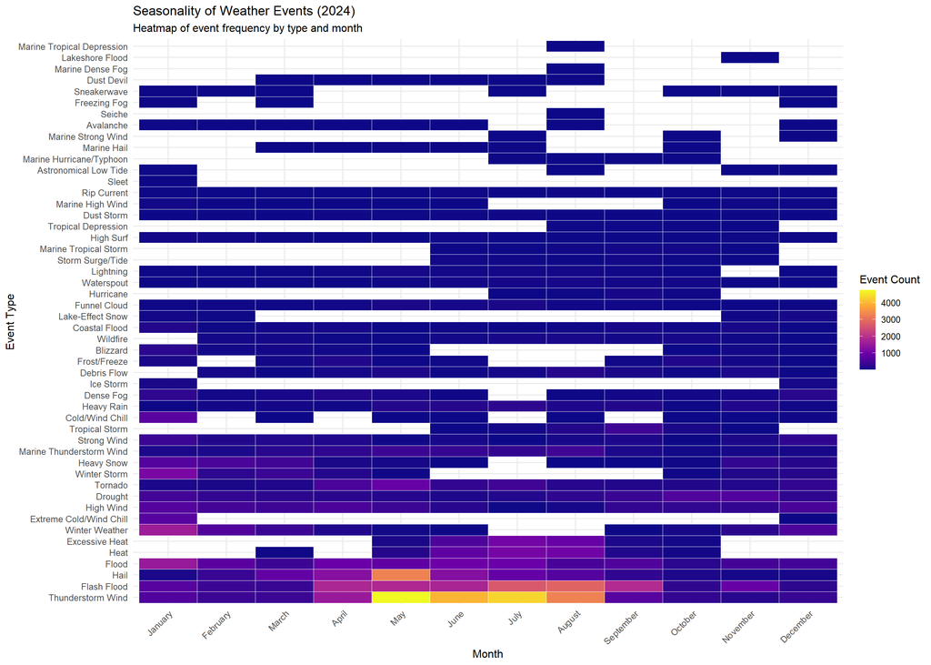

```r
# Select the necessary columns for seasonal analysis.
seasonal_data <- joined_data_cleaned %>%
  select(EVENT_TYPE, MONTH_NAME) %>%
  filter(!is.na(MONTH_NAME), !is.na(EVENT_TYPE))

# Count the frequency of each event type by month.
event_monthly_counts <- seasonal_data %>%
  group_by(EVENT_TYPE, MONTH_NAME) %>%
  summarise(EVENT_COUNT = n(), .groups = "drop")

# Convert MONTH_NAME to an ordered factor from January to December.
event_monthly_counts$MONTH_NAME <- factor(
  event_monthly_counts$MONTH_NAME,
  levels = month.name,
  ordered = TRUE
)

# Plot a heatmap to show event frequency by month and event type.
ggplot(event_monthly_counts, aes(x = MONTH_NAME, y = reorder(EVENT_TYPE, -EVENT_COUNT), fill = EVENT_COUNT)) +
  geom_tile(color = "white") +
  scale_fill_viridis_c(option = "C") +
  labs(
    title = "Seasonality of Weather Events (2024)",
    subtitle = "Heatmap of event frequency by type and month",
    x = "Month",
    y = "Event Type",
    fill = "Event Count"
  ) +
  theme_minimal(base_size = 12) +
  theme(axis.text.x = element_text(angle = 45, hjust = 1))
```

The seasonality heatmap reveals the monthly distribution of storm events by type throughout 2024. Clear temporal patterns emerge — for example, thunderstorm wind events cluster heavily in spring and summer months, while winter storms and ice storms are concentrated in colder months. This visualization helps illustrate the cyclical nature of various hazards over the calendar year, offering insight into when different event types tend to occur most often.

### Question 4: Which Event Types Are Associated with the Greatest Economic Damage?

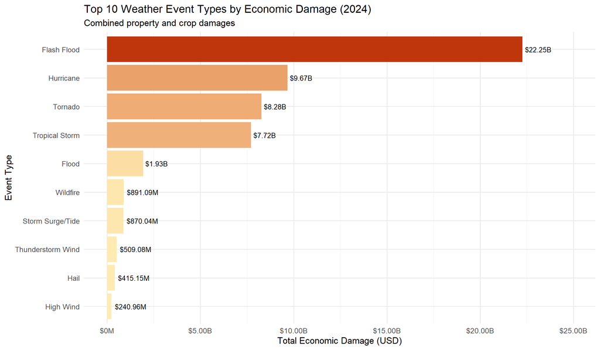

```r
# Define a function to convert damage strings (e.g., "10K", "1.5M") to numeric values.
convert_damage <- function(damage) {
  damage <- toupper(trimws(damage))
  numeric_value <- as.numeric(gsub("[KMB]", "", damage))
  multiplier <- case_when(
    grepl("K", damage) ~ 1e3,
    grepl("M", damage) ~ 1e6,
    grepl("B", damage) ~ 1e9,
    TRUE ~ 1
  )
  numeric_value * multiplier
}

# Select columns relevant to economic damage.
economic_data <- joined_data_cleaned %>%
  select(EVENT_TYPE, DAMAGE_PROPERTY, DAMAGE_CROPS) %>%
  mutate(
    PROP_DMG_NUM = ifelse(is.na(DAMAGE_PROPERTY), NA, convert_damage(DAMAGE_PROPERTY)),
    CROP_DMG_NUM = ifelse(is.na(DAMAGE_CROPS), NA, convert_damage(DAMAGE_CROPS)),
    TOTAL_ECONOMIC_DAMAGE = rowSums(cbind(PROP_DMG_NUM, CROP_DMG_NUM), na.rm = TRUE)
  )

# Summarize total economic damage by event type.
economic_summary <- economic_data %>%
  group_by(EVENT_TYPE) %>%
  summarise(
    TOTAL_PROPERTY_DAMAGE = sum(PROP_DMG_NUM, na.rm = TRUE),
    TOTAL_CROP_DAMAGE = sum(CROP_DMG_NUM, na.rm = TRUE),
    TOTAL_ECONOMIC_DAMAGE = sum(TOTAL_ECONOMIC_DAMAGE, na.rm = TRUE)
  ) %>%
  arrange(desc(TOTAL_ECONOMIC_DAMAGE))

# Function to format dollar amounts for the labels.
format_dollars <- function(x) {
  ifelse(x >= 1e9,
         dollar(x, scale = 1e-9, suffix = "B"),
         dollar(x, scale = 1e-6, suffix = "M"))
}

# Plot the top 10 event types by economic damage.
economic_summary %>%
  slice_max(TOTAL_ECONOMIC_DAMAGE, n = 10) %>%
  ggplot(aes(x = reorder(EVENT_TYPE, TOTAL_ECONOMIC_DAMAGE), y = TOTAL_ECONOMIC_DAMAGE, fill = TOTAL_ECONOMIC_DAMAGE)) +
  geom_col(show.legend = FALSE) +
  geom_text(aes(label = format_dollars(TOTAL_ECONOMIC_DAMAGE)), hjust = -0.1, size = 3.5, color = "black") +
  coord_flip() +
  labs(
    title = "Top 10 Weather Event Types by Economic Damage (2024)",
    subtitle = "Combined property and crop damages",
    x = "Event Type",
    y = "Total Economic Damage (USD)"
  ) +
  scale_fill_gradient(low = "#FFECB3", high = "#BF360C") +
  scale_y_continuous(labels = format_dollars) +
  theme_minimal(base_size = 13) +
  expand_limits(y = max(economic_summary$TOTAL_ECONOMIC_DAMAGE) * 1.12)
```

## Conclusion

This analysis of the 2024 NOAA Storm Events dataset provides a comprehensive overview of storm-related impacts across the United States. By integrating data from event details, locations, and fatalities, we examined the most harmful event types to population health, identified state-specific frequency patterns, uncovered seasonal trends, and quantified the economic consequences of severe weather.

The findings reveal clear geographic and temporal variability in how different hazards manifest, with events like tornadoes, heat, hail, and thunderstorm winds recurring prominently across multiple dimensions of impact. These insights may support future situational awareness efforts by municipal and emergency management professionals.

All results were generated through reproducible code applied to the raw NOAA files, ensuring transparency and traceability of every analytical step.